# Risk Factor Analysis

## Outcome Variable

**Outcome Variable:** ever_sstunted

## Predictor Variables

**Intervention Variable:** hfoodsec

**Adjustment Set:**

- arm
- sex
- W_mage
- meducyrs
- feducyrs
- hhwealth_quart
- vagbrth
- W_nrooms
- W_nchldlt5
- brthmon
- W_parity
- impfloor
- impsan
- safeh20
- delta_W_mage
- delta_meducyrs
- delta_feducyrs
- delta_hhwealth_quart
- delta_vagbrth
- delta_W_nrooms
- delta_W_nchldlt5
- delta_brthmon
- delta_W_parity
- delta_impfloor
- delta_impsan
- delta_safeh20

## Stratifying Variables

The analysis was stratified on these variable(s):

- agecat
- studyid
- country

## Data Summary

| agecat | studyid | country | hfoodsec | ever_sstunted | n_cell | n |
| --- | --- | --- | --- | --- | --- | --- |
| 0-24 months | ki0047075b-MAL-ED | BANGLADESH | Food Secure | 0 | 132 | 194 |
| 0-24 months | ki0047075b-MAL-ED | BANGLADESH | Food Secure | 1 | 29 | 194 |
| 0-24 months | ki0047075b-MAL-ED | BANGLADESH | Mildly Food Insecure | 0 | 2 | 194 |
| 0-24 months | ki0047075b-MAL-ED | BANGLADESH | Mildly Food Insecure | 1 | 2 | 194 |
| 0-24 months | ki0047075b-MAL-ED | BANGLADESH | Food Insecure | 0 | 17 | 194 |
| 0-24 months | ki0047075b-MAL-ED | BANGLADESH | Food Insecure | 1 | 12 | 194 |
| 0-24 months | ki0047075b-MAL-ED | BRAZIL | Food Secure | 0 | 3 | 129 |
| 0-24 months | ki0047075b-MAL-ED | BRAZIL | Food Secure | 1 | 0 | 129 |
| 0-24 months | ki0047075b-MAL-ED | BRAZIL | Mildly Food Insecure | 0 | 9 | 129 |
| 0-24 months | ki0047075b-MAL-ED | BRAZIL | Mildly Food Insecure | 1 | 2 | 129 |
| 0-24 months | ki0047075b-MAL-ED | BRAZIL | Food Insecure | 0 | 108 | 129 |
| 0-24 months | ki0047075b-MAL-ED | BRAZIL | Food Insecure | 1 | 7 | 129 |
| 0-24 months | ki0047075b-MAL-ED | INDIA | Food Secure | 0 | 145 | 212 |
| 0-24 months | ki0047075b-MAL-ED | INDIA | Food Secure | 1 | 45 | 212 |
| 0-24 months | ki0047075b-MAL-ED | INDIA | Mildly Food Insecure | 0 | 5 | 212 |
| 0-24 months | ki0047075b-MAL-ED | INDIA | Mildly Food Insecure | 1 | 0 | 212 |
| 0-24 months | ki0047075b-MAL-ED | INDIA | Food Insecure | 0 | 13 | 212 |
| 0-24 months | ki0047075b-MAL-ED | INDIA | Food Insecure | 1 | 4 | 212 |
| 0-24 months | ki0047075b-MAL-ED | NEPAL | Food Secure | 0 | 86 | 128 |
| 0-24 months | ki0047075b-MAL-ED | NEPAL | Food Secure | 1 | 8 | 128 |
| 0-24 months | ki0047075b-MAL-ED | NEPAL | Mildly Food Insecure | 0 | 15 | 128 |
| 0-24 months | ki0047075b-MAL-ED | NEPAL | Mildly Food Insecure | 1 | 0 | 128 |
| 0-24 months | ki0047075b-MAL-ED | NEPAL | Food Insecure | 0 | 13 | 128 |
| 0-24 months | ki0047075b-MAL-ED | NEPAL | Food Insecure | 1 | 6 | 128 |
| 0-24 months | ki0047075b-MAL-ED | PERU | Food Secure | 0 | 18 | 113 |
| 0-24 months | ki0047075b-MAL-ED | PERU | Food Secure | 1 | 9 | 113 |
| 0-24 months | ki0047075b-MAL-ED | PERU | Mildly Food Insecure | 0 | 24 | 113 |
| 0-24 months | ki0047075b-MAL-ED | PERU | Mildly Food Insecure | 1 | 5 | 113 |
| 0-24 months | ki0047075b-MAL-ED | PERU | Food Insecure | 0 | 39 | 113 |
| 0-24 months | ki0047075b-MAL-ED | PERU | Food Insecure | 1 | 18 | 113 |

[output cut: 102 more lines]

The following strata were considered:

- agecat: 0-24 months, studyid: ki0047075b-MAL-ED, country: BANGLADESH
- agecat: 0-24 months, studyid: ki0047075b-MAL-ED, country: BRAZIL
- agecat: 0-24 months, studyid: ki0047075b-MAL-ED, country: INDIA
- agecat: 0-24 months, studyid: ki0047075b-MAL-ED, country: NEPAL
- agecat: 0-24 months, studyid: ki0047075b-MAL-ED, country: PERU
- agecat: 0-24 months, studyid: ki0047075b-MAL-ED, country: SOUTH AFRICA
- agecat: 0-24 months, studyid: ki1017093-NIH-Birth, country: BANGLADESH
- agecat: 0-24 months, studyid: ki1017093c-NIH-Crypto, country: BANGLADESH
- agecat: 0-24 months, studyid: ki1113344-GMS-Nepal, country: NEPAL
- agecat: 0-24 months, studyid: kiGH5241-JiVitA-3, country: BANGLADESH
- agecat: 0-24 months, studyid: kiGH5241-JiVitA-4, country: BANGLADESH
- agecat: 0-6 months, studyid: ki0047075b-MAL-ED, country: BANGLADESH
- agecat: 0-6 months, studyid: ki0047075b-MAL-ED, country: BRAZIL
- agecat: 0-6 months, studyid: ki0047075b-MAL-ED, country: INDIA
- agecat: 0-6 months, studyid: ki0047075b-MAL-ED, country: NEPAL
- agecat: 0-6 months, studyid: ki0047075b-MAL-ED, country: PERU
- agecat: 0-6 months, studyid: ki0047075b-MAL-ED, country: SOUTH AFRICA
- agecat: 0-6 months, studyid: ki1017093-NIH-Birth, country: BANGLADESH
- agecat: 0-6 months, studyid: ki1017093c-NIH-Crypto, country: BANGLADESH
- agecat: 0-6 months, studyid: ki1113344-GMS-Nepal, country: NEPAL
- agecat: 0-6 months, studyid: kiGH5241-JiVitA-3, country: BANGLADESH
- agecat: 0-6 months, studyid: kiGH5241-JiVitA-4, country: BANGLADESH

### Dropped Strata

Some strata were dropped due to rare outcomes:

- agecat: 0-24 months, studyid: ki0047075b-MAL-ED, country: BANGLADESH
- agecat: 0-24 months, studyid: ki0047075b-MAL-ED, country: BRAZIL
- agecat: 0-24 months, studyid: ki0047075b-MAL-ED, country: INDIA
- agecat: 0-24 months, studyid: ki0047075b-MAL-ED, country: NEPAL
- agecat: 0-6 months, studyid: ki0047075b-MAL-ED, country: BANGLADESH
- agecat: 0-6 months, studyid: ki0047075b-MAL-ED, country: BRAZIL
- agecat: 0-6 months, studyid: ki0047075b-MAL-ED, country: INDIA
- agecat: 0-6 months, studyid: ki0047075b-MAL-ED, country: NEPAL
- agecat: 0-6 months, studyid: ki0047075b-MAL-ED, country: PERU
- agecat: 0-6 months, studyid: ki0047075b-MAL-ED, country: SOUTH AFRICA

## Methods Detail

We’re interested in the causal parameters $E[Y_a]$ for all values of $a \in \mathcal{A}$. These parameters represent the mean outcome if, possibly contrary to fact, we intervened to set all units to have $A=a$. Under the randomization and positivity assumptions, these are identified by the statistical parameters $\psi_a=E_W[E_{Y|A,W}(Y|A=a,W)]$. In addition, we’re interested in the mean of $Y$, $E[Y]$ under no intervention (the observed mean). We will estimate these parameters by using SuperLearner to fit the relevant likelihood factors – $E_{Y|A,W}(Y|A=a,W)$ and $p(A=a|W)$, and then updating our likelihood fit using a joint TMLE.

For unadjusted analyses ($W=\{\}$), initial likelihoods were estimated using Lrnr_glm to estimate the simple $E(Y|A)$ and Lrnr_mean to estimate $p(A)$. For adjusted analyses, a small library containing Lrnr_glmnet, Lrnr_xgboost, and Lrnr_mean was used.

Having estimated these parameters, we will then use the delta method to estimate relative risks and attributable risks relative to a prespecified baseline level of $A$.

# Results Detail

## Results Plots

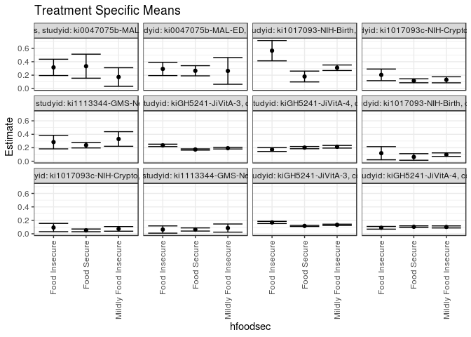

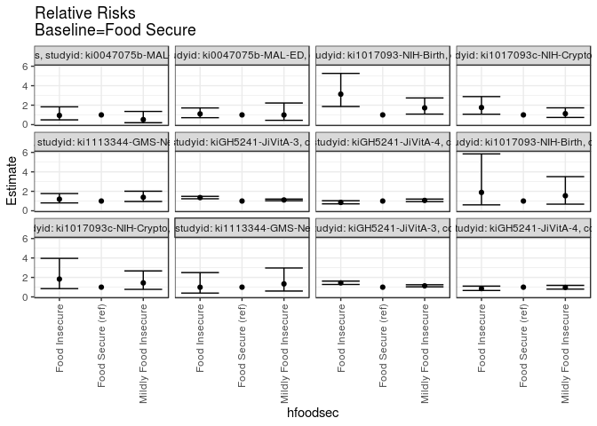

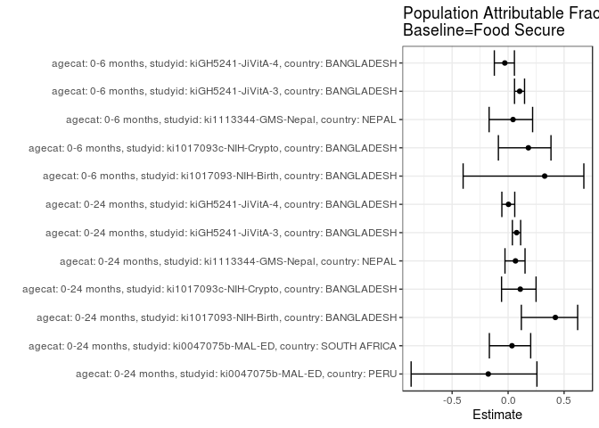

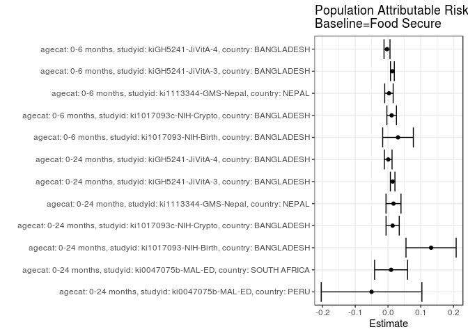

## Results Table

### Parameter: TSM

| agecat | studyid | country | intervention_level | baseline_level | estimate | ci_lower | ci_upper |
| --- | --- | --- | --- | --- | --- | --- | --- |
| 0-24 months | ki0047075b-MAL-ED | PERU | Food Secure | NA | 0.3333333 | 0.1547298 | 0.5119369 |
| 0-24 months | ki0047075b-MAL-ED | PERU | Mildly Food Insecure | NA | 0.1724138 | 0.0343207 | 0.3105069 |
| 0-24 months | ki0047075b-MAL-ED | PERU | Food Insecure | NA | 0.3157895 | 0.1945806 | 0.4369984 |
| 0-24 months | ki0047075b-MAL-ED | SOUTH AFRICA | Food Secure | NA | 0.2651515 | 0.1896873 | 0.3406157 |
| 0-24 months | ki0047075b-MAL-ED | SOUTH AFRICA | Mildly Food Insecure | NA | 0.2631579 | 0.0647309 | 0.4615849 |
| 0-24 months | ki0047075b-MAL-ED | SOUTH AFRICA | Food Insecure | NA | 0.2926829 | 0.1939912 | 0.3913747 |
| 0-24 months | ki1017093-NIH-Birth | BANGLADESH | Food Secure | NA | 0.1800710 | 0.0997733 | 0.2603688 |
| 0-24 months | ki1017093-NIH-Birth | BANGLADESH | Mildly Food Insecure | NA | 0.3100408 | 0.2690589 | 0.3510226 |
| 0-24 months | ki1017093-NIH-Birth | BANGLADESH | Food Insecure | NA | 0.5640928 | 0.4129268 | 0.7152589 |
| 0-24 months | ki1017093c-NIH-Crypto | BANGLADESH | Food Secure | NA | 0.1163921 | 0.0867236 | 0.1460606 |
| 0-24 months | ki1017093c-NIH-Crypto | BANGLADESH | Mildly Food Insecure | NA | 0.1310347 | 0.0860486 | 0.1760207 |
| 0-24 months | ki1017093c-NIH-Crypto | BANGLADESH | Food Insecure | NA | 0.2044967 | 0.1179490 | 0.2910445 |
| 0-24 months | ki1113344-GMS-Nepal | NEPAL | Food Secure | NA | 0.2382996 | 0.1974790 | 0.2791202 |
| 0-24 months | ki1113344-GMS-Nepal | NEPAL | Mildly Food Insecure | NA | 0.3301854 | 0.2218317 | 0.4385390 |
| 0-24 months | ki1113344-GMS-Nepal | NEPAL | Food Insecure | NA | 0.2844276 | 0.1836575 | 0.3851977 |
| 0-24 months | kiGH5241-JiVitA-3 | BANGLADESH | Food Secure | NA | 0.1740748 | 0.1646177 | 0.1835320 |
| 0-24 months | kiGH5241-JiVitA-3 | BANGLADESH | Mildly Food Insecure | NA | 0.1933622 | 0.1818362 | 0.2048882 |
| 0-24 months | kiGH5241-JiVitA-3 | BANGLADESH | Food Insecure | NA | 0.2354167 | 0.2176408 | 0.2531926 |
| 0-24 months | kiGH5241-JiVitA-4 | BANGLADESH | Food Secure | NA | 0.2023438 | 0.1855455 | 0.2191422 |
| 0-24 months | kiGH5241-JiVitA-4 | BANGLADESH | Mildly Food Insecure | NA | 0.2148771 | 0.1951424 | 0.2346118 |
| 0-24 months | kiGH5241-JiVitA-4 | BANGLADESH | Food Insecure | NA | 0.1732087 | 0.1453361 | 0.2010812 |
| 0-6 months | ki1017093-NIH-Birth | BANGLADESH | Food Secure | NA | 0.0631579 | 0.0142050 | 0.1121108 |
| 0-6 months | ki1017093-NIH-Birth | BANGLADESH | Mildly Food Insecure | NA | 0.0975610 | 0.0713213 | 0.1238006 |
| 0-6 months | ki1017093-NIH-Birth | BANGLADESH | Food Insecure | NA | 0.1190476 | 0.0210297 | 0.2170655 |
| 0-6 months | ki1017093c-NIH-Crypto | BANGLADESH | Food Secure | NA | 0.0507726 | 0.0305431 | 0.0710021 |
| 0-6 months | ki1017093c-NIH-Crypto | BANGLADESH | Mildly Food Insecure | NA | 0.0730594 | 0.0385707 | 0.1075480 |
| 0-6 months | ki1017093c-NIH-Crypto | BANGLADESH | Food Insecure | NA | 0.0930233 | 0.0315934 | 0.1544531 |
| 0-6 months | ki1113344-GMS-Nepal | NEPAL | Food Secure | NA | 0.0638298 | 0.0405146 | 0.0871450 |
| 0-6 months | ki1113344-GMS-Nepal | NEPAL | Mildly Food Insecure | NA | 0.0853659 | 0.0248347 | 0.1458970 |
| 0-6 months | ki1113344-GMS-Nepal | NEPAL | Food Insecure | NA | 0.0632911 | 0.0095533 | 0.1170290 |
| 0-6 months | kiGH5241-JiVitA-3 | BANGLADESH | Food Secure | NA | 0.1169722 | 0.1089371 | 0.1250074 |
| 0-6 months | kiGH5241-JiVitA-3 | BANGLADESH | Mildly Food Insecure | NA | 0.1330446 | 0.1234821 | 0.1426072 |
| 0-6 months | kiGH5241-JiVitA-3 | BANGLADESH | Food Insecure | NA | 0.1687051 | 0.1524726 | 0.1849377 |
| 0-6 months | kiGH5241-JiVitA-4 | BANGLADESH | Food Secure | NA | 0.1045157 | 0.0914603 | 0.1175712 |
| 0-6 months | kiGH5241-JiVitA-4 | BANGLADESH | Mildly Food Insecure | NA | 0.1018334 | 0.0866180 | 0.1170487 |
| 0-6 months | kiGH5241-JiVitA-4 | BANGLADESH | Food Insecure | NA | 0.0892459 | 0.0693090 | 0.1091828 |

### Parameter: E(Y)

| agecat | studyid | country | intervention_level | baseline_level | estimate | ci_lower | ci_upper |
| --- | --- | --- | --- | --- | --- | --- | --- |
| 0-24 months | ki0047075b-MAL-ED | PERU | NA | NA | 0.2831858 | 0.1997451 | 0.3666266 |
| 0-24 months | ki0047075b-MAL-ED | SOUTH AFRICA | NA | NA | 0.2746781 | 0.2172425 | 0.3321138 |
| 0-24 months | ki1017093-NIH-Birth | BANGLADESH | NA | NA | 0.3116057 | 0.2753823 | 0.3478292 |
| 0-24 months | ki1017093c-NIH-Crypto | BANGLADESH | NA | NA | 0.1306069 | 0.1066024 | 0.1546113 |
| 0-24 months | ki1113344-GMS-Nepal | NEPAL | NA | NA | 0.2551370 | 0.2197504 | 0.2905236 |
| 0-24 months | kiGH5241-JiVitA-3 | BANGLADESH | NA | NA | 0.1883666 | 0.1814510 | 0.1952822 |
| 0-24 months | kiGH5241-JiVitA-4 | BANGLADESH | NA | NA | 0.2030382 | 0.1911640 | 0.2149123 |
| 0-6 months | ki1017093-NIH-Birth | BANGLADESH | NA | NA | 0.0937997 | 0.0709973 | 0.1166021 |
| 0-6 months | ki1017093c-NIH-Crypto | BANGLADESH | NA | NA | 0.0620053 | 0.0448256 | 0.0791849 |
| 0-6 months | ki1113344-GMS-Nepal | NEPAL | NA | NA | 0.0667808 | 0.0465165 | 0.0870451 |
| 0-6 months | kiGH5241-JiVitA-3 | BANGLADESH | NA | NA | 0.1304423 | 0.1246194 | 0.1362652 |
| 0-6 months | kiGH5241-JiVitA-4 | BANGLADESH | NA | NA | 0.1015318 | 0.0925643 | 0.1104993 |

### Parameter: RR

| agecat | studyid | country | intervention_level | baseline_level | estimate | ci_lower | ci_upper |
| --- | --- | --- | --- | --- | --- | --- | --- |
| 0-24 months | ki0047075b-MAL-ED | PERU | Food Secure | Food Secure | 1.0000000 | 1.0000000 | 1.000000 |
| 0-24 months | ki0047075b-MAL-ED | PERU | Mildly Food Insecure | Food Secure | 0.5172414 | 0.1973289 | 1.355801 |
| 0-24 months | ki0047075b-MAL-ED | PERU | Food Insecure | Food Secure | 0.9473684 | 0.4900879 | 1.831318 |
| 0-24 months | ki0047075b-MAL-ED | SOUTH AFRICA | Food Secure | Food Secure | 1.0000000 | 1.0000000 | 1.000000 |
| 0-24 months | ki0047075b-MAL-ED | SOUTH AFRICA | Mildly Food Insecure | Food Secure | 0.9924812 | 0.4433061 | 2.221984 |
| 0-24 months | ki0047075b-MAL-ED | SOUTH AFRICA | Food Insecure | Food Secure | 1.1038328 | 0.7100190 | 1.716076 |
| 0-24 months | ki1017093-NIH-Birth | BANGLADESH | Food Secure | Food Secure | 1.0000000 | 1.0000000 | 1.000000 |
| 0-24 months | ki1017093-NIH-Birth | BANGLADESH | Mildly Food Insecure | Food Secure | 1.7217692 | 1.0810895 | 2.742131 |
| 0-24 months | ki1017093-NIH-Birth | BANGLADESH | Food Insecure | Food Secure | 3.1326128 | 1.8633153 | 5.266560 |
| 0-24 months | ki1017093c-NIH-Crypto | BANGLADESH | Food Secure | Food Secure | 1.0000000 | 1.0000000 | 1.000000 |
| 0-24 months | ki1017093c-NIH-Crypto | BANGLADESH | Mildly Food Insecure | Food Secure | 1.1258041 | 0.7341081 | 1.726496 |
| 0-24 months | ki1017093c-NIH-Crypto | BANGLADESH | Food Insecure | Food Secure | 1.7569644 | 1.0718304 | 2.880049 |
| 0-24 months | ki1113344-GMS-Nepal | NEPAL | Food Secure | Food Secure | 1.0000000 | 1.0000000 | 1.000000 |
| 0-24 months | ki1113344-GMS-Nepal | NEPAL | Mildly Food Insecure | Food Secure | 1.3855892 | 0.9564330 | 2.007310 |
| 0-24 months | ki1113344-GMS-Nepal | NEPAL | Food Insecure | Food Secure | 1.1935714 | 0.8053926 | 1.768843 |
| 0-24 months | kiGH5241-JiVitA-3 | BANGLADESH | Food Secure | Food Secure | 1.0000000 | 1.0000000 | 1.000000 |
| 0-24 months | kiGH5241-JiVitA-3 | BANGLADESH | Mildly Food Insecure | Food Secure | 1.1107990 | 1.0291546 | 1.198920 |
| 0-24 months | kiGH5241-JiVitA-3 | BANGLADESH | Food Insecure | Food Secure | 1.3523880 | 1.2333528 | 1.482912 |
| 0-24 months | kiGH5241-JiVitA-4 | BANGLADESH | Food Secure | Food Secure | 1.0000000 | 1.0000000 | 1.000000 |
| 0-24 months | kiGH5241-JiVitA-4 | BANGLADESH | Mildly Food Insecure | Food Secure | 1.0619406 | 0.9395299 | 1.200300 |
| 0-24 months | kiGH5241-JiVitA-4 | BANGLADESH | Food Insecure | Food Secure | 0.8560116 | 0.7115990 | 1.029731 |
| 0-6 months | ki1017093-NIH-Birth | BANGLADESH | Food Secure | Food Secure | 1.0000000 | 1.0000000 | 1.000000 |
| 0-6 months | ki1017093-NIH-Birth | BANGLADESH | Mildly Food Insecure | Food Secure | 1.5447154 | 0.6800516 | 3.508772 |
| 0-6 months | ki1017093-NIH-Birth | BANGLADESH | Food Insecure | Food Secure | 1.8849206 | 0.6084161 | 5.839632 |
| 0-6 months | ki1017093c-NIH-Crypto | BANGLADESH | Food Secure | Food Secure | 1.0000000 | 1.0000000 | 1.000000 |
| 0-6 months | ki1017093c-NIH-Crypto | BANGLADESH | Mildly Food Insecure | Food Secure | 1.4389518 | 0.7758332 | 2.668850 |
| 0-6 months | ki1017093c-NIH-Crypto | BANGLADESH | Food Insecure | Food Secure | 1.8321537 | 0.8472446 | 3.962005 |
| 0-6 months | ki1113344-GMS-Nepal | NEPAL | Food Secure | Food Secure | 1.0000000 | 1.0000000 | 1.000000 |
| 0-6 months | ki1113344-GMS-Nepal | NEPAL | Mildly Food Insecure | Food Secure | 1.3373984 | 0.6023565 | 2.969395 |
| 0-6 months | ki1113344-GMS-Nepal | NEPAL | Food Insecure | Food Secure | 0.9915612 | 0.3934620 | 2.498827 |
| 0-6 months | kiGH5241-JiVitA-3 | BANGLADESH | Food Secure | Food Secure | 1.0000000 | 1.0000000 | 1.000000 |
| 0-6 months | kiGH5241-JiVitA-3 | BANGLADESH | Mildly Food Insecure | Food Secure | 1.1374034 | 1.0337081 | 1.251501 |
| 0-6 months | kiGH5241-JiVitA-3 | BANGLADESH | Food Insecure | Food Secure | 1.4422664 | 1.2819079 | 1.622685 |
| 0-6 months | kiGH5241-JiVitA-4 | BANGLADESH | Food Secure | Food Secure | 1.0000000 | 1.0000000 | 1.000000 |
| 0-6 months | kiGH5241-JiVitA-4 | BANGLADESH | Mildly Food Insecure | Food Secure | 0.9743353 | 0.7999087 | 1.186797 |
| 0-6 months | kiGH5241-JiVitA-4 | BANGLADESH | Food Insecure | Food Secure | 0.8538996 | 0.6593599 | 1.105837 |

### Parameter: PAR

| agecat | studyid | country | intervention_level | baseline_level | estimate | ci_lower | ci_upper |
| --- | --- | --- | --- | --- | --- | --- | --- |
| 0-24 months | ki0047075b-MAL-ED | PERU | Food Secure | NA | -0.0501475 | -0.2038280 | 0.1035331 |
| 0-24 months | ki0047075b-MAL-ED | SOUTH AFRICA | Food Secure | NA | 0.0095266 | -0.0408834 | 0.0599366 |
| 0-24 months | ki1017093-NIH-Birth | BANGLADESH | Food Secure | NA | 0.1315347 | 0.0549715 | 0.2080979 |
| 0-24 months | ki1017093c-NIH-Crypto | BANGLADESH | Food Secure | NA | 0.0142148 | -0.0059222 | 0.0343518 |
| 0-24 months | ki1113344-GMS-Nepal | NEPAL | Food Secure | NA | 0.0168374 | -0.0060176 | 0.0396923 |
| 0-24 months | kiGH5241-JiVitA-3 | BANGLADESH | Food Secure | NA | 0.0142918 | 0.0073256 | 0.0212579 |
| 0-24 months | kiGH5241-JiVitA-4 | BANGLADESH | Food Secure | NA | 0.0006943 | -0.0109903 | 0.0123790 |
| 0-6 months | ki1017093-NIH-Birth | BANGLADESH | Food Secure | NA | 0.0306418 | -0.0161820 | 0.0774656 |
| 0-6 months | ki1017093c-NIH-Crypto | BANGLADESH | Food Secure | NA | 0.0112327 | -0.0034383 | 0.0259036 |
| 0-6 months | ki1113344-GMS-Nepal | NEPAL | Food Secure | NA | 0.0029510 | -0.0099628 | 0.0158649 |
| 0-6 months | kiGH5241-JiVitA-3 | BANGLADESH | Food Secure | NA | 0.0134701 | 0.0076362 | 0.0193040 |
| 0-6 months | kiGH5241-JiVitA-4 | BANGLADESH | Food Secure | NA | -0.0029839 | -0.0120917 | 0.0061238 |

### Parameter: PAF

| agecat | studyid | country | intervention_level | baseline_level | estimate | ci_lower | ci_upper |
| --- | --- | --- | --- | --- | --- | --- | --- |
| 0-24 months | ki0047075b-MAL-ED | PERU | Food Secure | NA | -0.1770833 | -0.8662521 | 0.2575895 |
| 0-24 months | ki0047075b-MAL-ED | SOUTH AFRICA | Food Secure | NA | 0.0346828 | -0.1674004 | 0.2017843 |
| 0-24 months | ki1017093-NIH-Birth | BANGLADESH | Food Secure | NA | 0.4221190 | 0.1182549 | 0.6212664 |
| 0-24 months | ki1017093c-NIH-Crypto | BANGLADESH | Food Secure | NA | 0.1088364 | -0.0585288 | 0.2497393 |
| 0-24 months | ki1113344-GMS-Nepal | NEPAL | Food Secure | NA | 0.0659935 | -0.0278624 | 0.1512793 |
| 0-24 months | kiGH5241-JiVitA-3 | BANGLADESH | Food Secure | NA | 0.0758721 | 0.0382394 | 0.1120323 |
| 0-24 months | kiGH5241-JiVitA-4 | BANGLADESH | Food Secure | NA | 0.0034197 | -0.0558274 | 0.0593422 |
| 0-6 months | ki1017093-NIH-Birth | BANGLADESH | Food Secure | NA | 0.3266726 | -0.4017699 | 0.6765733 |
| 0-6 months | ki1017093c-NIH-Crypto | BANGLADESH | Food Secure | NA | 0.1811564 | -0.0867976 | 0.3830453 |
| 0-6 months | ki1113344-GMS-Nepal | NEPAL | Food Secure | NA | 0.0441899 | -0.1696451 | 0.2189314 |
| 0-6 months | kiGH5241-JiVitA-3 | BANGLADESH | Food Secure | NA | 0.1032646 | 0.0573978 | 0.1468995 |
| 0-6 months | kiGH5241-JiVitA-4 | BANGLADESH | Food Secure | NA | -0.0293889 | -0.1230351 | 0.0564484 |